# Análise do efeito de escolas católicas no desempenho dos alunos usando Propensity Score Matching

# 1 Introdução

Na ciência de dados, um dos grandes desafios é entender a *relação causal* entre variáveis. Em muitos casos, não podemos realizar experimentos controlados devido a limitações éticas, financeiras ou logísticas. Por isso, os pesquisadores utilizam estudos observacionais, que, embora úteis, nem sempre garantem a equivalência entre os grupos comparados, podendo introduzir vieses que dificultam a interpretação dos resultados.

Para superar esse desafio, aplicamos técnicas de *inferência causal*, que permitem estimar o impacto de uma variável (o tratamento) controlando possíveis influências externas. Neste projeto, utilizamos o Propensity Score Matching (PSM) para tentar equilibrar as características dos grupos de tratamento e controle, facilitando a comparação e tornando a análise mais robusta.

# 2 Objetivo

O objetivo deste estudo é analisar o efeito de frequentar uma escola católica no desempenho acadêmico dos alunos, em comparação com aqueles que frequentam escolas não católicas. Ao usar o Propensity Score Matching, buscamos obter estimativas mais confiáveis, controlando fatores que possam influenciar o desempenho acadêmico, como renda familiar, raça, e nível de educação dos pais.

# 3 Contexto do Problema

Frequentar uma escola católica pode ter impactos diferentes no desempenho dos alunos em relação a escolas não católicas. Entretanto, os alunos que frequentam escolas católicas tendem a ter perfis socioeconômicos diferentes daqueles que frequentam outras instituições, o que pode gerar um viés na análise.

**Pergunta de Pesquisa**: A diferença de desempenho entre alunos de escolas católicas e não católicas é causada pela instituição de ensino ou por características pré-existentes dos alunos, como seu histórico familiar e socioeconômico?

Esse estudo busca esclarecer se o desempenho acadêmico dos alunos é fortemente influenciado pela escola que frequentam ou se é resultado de desigualdades que eles já trazem consigo.

# 4 Metodologia

## 4.1 Propensity Score Matching

O Propensity Score Matching é uma técnica que visa reduzir o viés de seleção em estudos observacionais. Quando os grupos de tratamento e controle não são formados aleatoriamente, é possível que as diferenças nos resultados sejam influenciadas por características externas. O PSM busca equilibrar essas características entre os grupos.

- **Modelo de Probabilidade**: O escore de propensão é calculado por meio de uma regressão logística, onde a variável dependente é a probabilidade de o aluno frequentar uma escola católica. As variáveis independentes incluem fatores como idade da mãe, renda familiar e raça.
- **Pareamento**: Após calcular os escores de propensão, pareamos os alunos de escolas católicas com aqueles de escolas não católicas que possuem escores semelhantes, formando pares comparáveis. Isso nos permite realizar uma comparação mais justa entre os grupos.

# 5 Tratamento dos dados

## 5.1 Variáveis utilizadas

**catholic**: Se a escola é católica (1) ou não (0);

**c5r2mtsc_std**: Notas padronizadas de matemática;

**p5hmage**: Idade da mãe;

**race_white**: Se aluno é da raça branca (1) ou não (0);

**w3income_1k**: Renda familiar (em milhares);

**p5numpla**: Número de lugares onde o aluno viveu por pelo menos 4 meses;

**w3momed_hsb**: O nível de educação da mãe é ensino médio ou menos (1) ou algum nível universitário ou superior (0)?

## 5.2 Leitura da Base de Dados

A base de dados `ecls` foi carregada e preparada para análise. A variável de interesse é a nota padronizada de matemática (c5r2mtsc_std), enquanto as demais variáveis servem como controles no cálculo do escore de propensão.

```r
library(kableExtra)  # Formatação de tabelas
library(MatchIt)     # Matching de dados em análises de causalidade
library(tidyverse)   # manipulação de dados
library(readr)       # usado para ler arquivos CSV
library(gt)

# Lê o arquivo CSV e armazena no dataframe 'ecls'
ecls <- read_csv("ecls.csv")

# Seleciona colunas específicas do dataframe 'ecls'
ecls <- ecls %>%
  select('catholic', 'c5r2mtsc_std', 'p5hmage',
         'race_white','w3income_1k', 'p5numpla', 'w3momed_hsb')

ecls %>% head(2) %>% gt() # Exibe as duas primeiras linhas
```

| catholic | c5r2mtsc_std | p5hmage | race_white | w3income_1k | p5numpla | w3momed_hsb |
| --- | --- | --- | --- | --- | --- | --- |
| 0 | 0.9817533 | 47 | 1 | 62.5005 | 1 | 0 |
| 0 | 0.5943775 | 41 | 1 | 45.0005 | 1 | 0 |

# 6 Análise e Resultados

## 6.1 Média das variáveis

### 6.1.1 Matemática

• As notas nos testes de **c5r2mtsc_std** (média padronizada de matemática, utilizando a padronização z) diferem, em média, entre alunos de escolas católicas e não católicas?

```r
ecls %>%
  group_by(catholic) %>%
  summarise(n_students = n(),
            mean_math = mean(c5r2mtsc_std),
            std_error = sd(c5r2mtsc_std) / sqrt(n_students)) %>% gt()
```

| catholic | n_students | mean_math | std_error |
| --- | --- | --- | --- |
| 0 | 4499 | 0.1631279 | 0.01451663 |
| 1 | 930 | 0.2196851 | 0.02813170 |

- A **média** das notas padronizadas de matemática é **maior** para alunos de **escolas católicas** (0.2197) do que para alunos de escolas não católicas (0.1631). No entanto, a significância dessa diferença ainda precisa ser verificada.

### 6.1.2 Demais variáveis

```r
ecls_cov <-c('race_white','p5hmage','w3income_1k','p5numpla','w3momed_hsb')

ecls %>%
  group_by(catholic) %>%
  select(one_of(ecls_cov)) %>%
  summarise_all(funs(mean(.,na.rm = T))) %>% gt()
```

| catholic | race_white | p5hmage | w3income_1k | p5numpla | w3momed_hsb |
| --- | --- | --- | --- | --- | --- |
| 0 | 0.6537008 | 37.79462 | 65.39393 | 1.106246 | 0.3923094 |
| 1 | 0.7666667 | 39.77527 | 86.18063 | 1.073118 | 0.2053763 |

- *race_white*: **A proporção de alunos brancos é maior em escolas católicas** (76.67%) do que em não católicas (65.37%). Isso sugere uma maior concentração de alunos brancos em escolas católicas, o que pode estar relacionado com fatores históricos, sociais ou econômicos.
- *Idade da mãe*: As mães de alunos em escolas católicas são um pouco mais velhas (39.78 anos) do que em escolas não católicas (37.79 anos), o que pode refletir diferenças socioeconômicas.
- *Renda familiar*: A renda é significativamente maior em escolas católicas (86.180) do que em escolas não católicas (65.393), influenciando o desempenho escolar.
- *Número de lugares vividos*: Alunos de escolas não católicas viveram em mais lugares (1.11) do que os de escolas católicas (1.07), indicando uma possível maior estabilidade em escolas católicas.
- *Escolaridade da mãe*: Mais mães em escolas católicas têm escolaridade superior ao ensino médio (79.46%) em comparação com escolas não católicas (60.77%).

Essas variáveis apontam para um perfil mais privilegiado dos alunos de escolas católicas em comparação com os de escolas não católicas.

Alunos de escolas católicas, em geral, têm maior probabilidade de serem brancos, terem mães mais velhas e com maior escolaridade, além de virem de famílias com rendas mais altas.

Esses fatores podem contribuir para o desempenho acadêmico superior observado nos testes de matemática, embora seja necessário um estudo mais aprofundado para confirmar essas relações e evitar conclusões simplistas.

## 6.2 Teste t

O teste t é uma ferramenta estatística usada para comparar a média de dois grupos e verificar se as diferenças observadas entre as médias são significativas ou podem ter ocorrido por acaso.

O que o teste t faz: - **Hipótese nula (H₀**): As médias dos dois grupos são iguais, ou seja, não há diferença significativa entre elas. - **Hipótese alternativa (H₁)**: As médias dos dois grupos são diferentes, ou seja, há uma diferença significativa entre elas.

- O teste calcula uma estatística chamada valor de **t** e um **p-valor**, que nos ajuda a decidir se devemos rejeitar a hipótese nula ou não.
  - Se **o p-valor** for menor que um certo nível de significância (geralmente 0.05 ou 5%), rejeitamos a hipótese nula e concluímos que as médias são significativamente diferentes.
  - Caso contrário, não há evidências suficientes para rejeitar a hipótese nula.

### 6.2.1 Média de matemática

```r
with(ecls, t.test(c5r2mtsc_std ~ catholic))
```

```
##
##  Welch Two Sample t-test
##
## data:  c5r2mtsc_std by catholic
## t = -1.7866, df = 1468.1, p-value = 0.07421
## alternative hypothesis: true difference in means between group 0 and group 1 is not equal to 0
## 95 percent confidence interval:
##  -0.118653665  0.005539377
## sample estimates:
## mean in group 0 mean in group 1
##       0.1631279       0.2196851
```

- **A diferença nas notas de matemática** entre alunos de escolas católicas (0,22) e não católicas (0,16) é pequena, e o teste t rejeita a hipótese de médias iguais apenas ao nível de significância de 10%, mas não ao de 5%.
- Isso sugere que a diferença **não é estatisticamente significativa** em um nível mais rigoroso, o que impede de afirmar com certeza que estudar em escola católica melhora o desempenho em matemática, já que a correlação pode ser casual mesmo considerando outros fatores.

### 6.2.2 Raça

```r
with(ecls, t.test(race_white ~ catholic)) # Raça branca
```

```
##
##  Welch Two Sample t-test
##
## data:  race_white by catholic
## t = -7.2484, df = 1457.5, p-value = 6.814e-13
## alternative hypothesis: true difference in means between group 0 and group 1 is not equal to 0
## 95 percent confidence interval:
##  -0.14353706 -0.08239463
## sample estimates:
## mean in group 0 mean in group 1
##       0.6537008       0.7666667
```

- A análise mostra que a proporção de alunos brancos é significativamente maior em escolas católicas (76,67%) do que em não católicas (65,37%), com um p-valor extremamente baixo que permite rejeitar a hipótese de não haver diferença.
- Assim, ser branco está estatisticamente associado a estudar em uma escola católica.

### 6.2.3 Idade da mãe

```r
with(ecls, t.test(p5hmage ~ catholic)) # Idade da mae
```

```
##
##  Welch Two Sample t-test
##
## data:  p5hmage by catholic
## t = -11.207, df = 1562.1, p-value < 2.2e-16
## alternative hypothesis: true difference in means between group 0 and group 1 is not equal to 0
## 95 percent confidence interval:
##  -2.327294 -1.634002
## sample estimates:
## mean in group 0 mean in group 1
##        37.79462        39.77527
```

- A análise revela que a idade média das mães de alunos em escolas católicas (39,78 anos) é significativamente maior do que a das mães de alunos de escolas não católicas (37,79 anos), com um p-valor extremamente baixo (2.2e-16).
- Isso permite rejeitar a hipótese de que não há diferença, concluindo que as mães de alunos em escolas católicas são, em média, mais velhas de forma estatisticamente significativa.

### 6.2.4 Renda familiar (em milhares)

```r
with(ecls, t.test(w3income_1k ~ catholic)) # Renda familiar
```

```
##
##  Welch Two Sample t-test
##
## data:  w3income_1k by catholic
## t = -13.238, df = 1314.5, p-value < 2.2e-16
## alternative hypothesis: true difference in means between group 0 and group 1 is not equal to 0
## 95 percent confidence interval:
##  -23.86719 -17.70620
## sample estimates:
## mean in group 0 mean in group 1
##        65.39393        86.18063
```

- A análise mostra que a renda familiar média dos alunos em escolas católicas (86.180,63) é significativamente maior que a dos alunos em escolas não católicas (65.393,93). Com uma estatística t de -13,24, o teste t indica que essa diferença é estatisticamente significativa, tornando improvável que seja devida ao acaso.
- Assim, frequentar uma escola católica está associado a uma renda familiar significativamente mais alta.

### 6.2.5 Quantidade de lugares em que alunos moraram

```r
with(ecls, t.test(p5numpla ~ catholic)) # Quantidade de lugares em que alunos moraram
```

```
##
##  Welch Two Sample t-test
##
## data:  p5numpla by catholic
## t = 3.128, df = 1600.4, p-value = 0.001792
## alternative hypothesis: true difference in means between group 0 and group 1 is not equal to 0
## 95 percent confidence interval:
##  0.01235472 0.05390038
## sample estimates:
## mean in group 0 mean in group 1
##        1.106246        1.073118
```

- A análise mostra que os alunos de escolas não católicas viveram, em média, em mais lugares (1,11) do que os alunos de escolas católicas (1,07). Com uma estatística t de 3,13, essa diferença é estatisticamente significativa, sugerindo que os alunos de escolas católicas tendem a ter vivido em menos lugares.
- Portanto, há uma diferença significativa no número de lugares onde os alunos viveram, com os de escolas não católicas tendo maior mobilidade.

### 6.2.6 Escolaridade da mãe até ensino médio (w3momed_hsb)

```r
with(ecls, t.test(w3momed_hsb ~ catholic)) # Escolaridade da mae
```

```
##
##  Welch Two Sample t-test
##
## data:  w3momed_hsb by catholic
## t = 12.362, df = 1545.1, p-value < 2.2e-16
## alternative hypothesis: true difference in means between group 0 and group 1 is not equal to 0
## 95 percent confidence interval:
##  0.1572715 0.2165946
## sample estimates:
## mean in group 0 mean in group 1
##       0.3923094       0.2053763
```

- A análise mostra que a proporção de mães com escolaridade até o ensino médio é maior entre alunos de escolas não católicas (39,23%) em comparação com escolas católicas (20,54%). Com uma estatística t de 12,36, a diferença é estatisticamente significativa, sugerindo que não é devida ao acaso.
- Portanto, a escolaridade das mães de alunos de escolas católicas é significativamente mais alta, indicando uma menor proporção de mães com escolaridade até o ensino médio nesse grupo.

## 6.3 O que isso significa?

Significa que simplesmente comparar a média de notas de alunos de escolas católicas com alunos de escolas não católicas não é uma abordagem adequada, pois **o contexto e o background desses alunos são diferentes**.

Para abordar essa questão, utilizaremos a estimativa de *propensity score*. Essa técnica nos permitirá criar um contrafactual, buscando entre todos os alunos que não frequentam escolas católicas aqueles que mais se assemelham ao perfil dos alunos de escolas católicas.

Dessa forma, poderemos realizar comparações mais justas e precisas.

# 7 Estimativa do Propensity Score

Na prática, o processo de Propensity Score Matching geralmente envolve os seguintes passos:

**Modelagem do Propensity Score**: Utilizar regressão logística ou outro modelo para calcular a probabilidade de receber o tratamento com base em variáveis observáveis.

**Matching**: Parear indivíduos tratados e não tratados com base em seus propensity scores, utilizando métodos como matching por pares, matching com reposição ou matching mais próximo.

**Análise de Resultados**: Comparar os resultados entre os grupos pareados para avaliar o efeito do tratamento.

## 7.1 Regressão logística

Queremos calcular um propensity score individual que nos forneça a probabilidade de um aluno ser ou não de escola católica, levando em consideração variáveis como raça, renda, idade da mãe e o número de lugares onde a pessoa morou.

```r
m_ps <- glm(catholic ~ race_white + w3income_1k + p5hmage + p5numpla + w3momed_hsb,
            family = binomial(),
            data=ecls) # modelo de regressão logística

ecls$pr_score<-predict(m_ps,type = "response")

summary(m_ps)
```

```
##
## Call:
## glm(formula = catholic ~ race_white + w3income_1k + p5hmage +
##     p5numpla + w3momed_hsb, family = binomial(), data = ecls)
##
## Deviance Residuals:
##     Min       1Q   Median       3Q      Max
## -1.2305  -0.6669  -0.5170  -0.3743   2.4825
##
## Coefficients:
##               Estimate Std. Error z value Pr(>|z|)
## (Intercept) -3.4092820  0.3263351 -10.447  < 2e-16 ***
## race_white   0.3001516  0.0870242   3.449 0.000563 ***
## w3income_1k  0.0063463  0.0008473   7.490 6.88e-14 ***
## p5hmage      0.0395347  0.0070820   5.582 2.37e-08 ***
## p5numpla    -0.2106296  0.1230279  -1.712 0.086888 .
## w3momed_hsb -0.5644212  0.0926141  -6.094 1.10e-09 ***
## ---
## Signif. codes:  0 '***' 0.001 '**' 0.01 '*' 0.05 '.' 0.1 ' ' 1
##
## (Dispersion parameter for binomial family taken to be 1)
##
##     Null deviance: 4972.4  on 5428  degrees of freedom
## Residual deviance: 4706.8  on 5423  degrees of freedom
## AIC: 4718.8
##
## Number of Fisher Scoring iterations: 5
```

- A raça do aluno (`race_white`) é significativa, sugerindo que alunos brancos têm uma maior probabilidade de estar em escolas católicas.
- A renda familiar (`w3income_1k`) também se mostrou altamente significativa, indicando que quanto maior a renda da família, maior a probabilidade de o aluno estar em uma escola católica.
- A idade da mãe (`p5hmage`) também influencia positivamente essa probabilidade.
- Por outro lado, o número de lugares onde o aluno viveu (`p5numpla`) não apresentou significância estatística ao nível de 5%, mas tem um impacto negativo marginal.
- Finalmente, o nível educacional da mãe (`w3momed_hsb`) mostrou-se significativo, revelando que filhos de mães com ensino médio ou menos têm menor chance de frequentar escolas católicas, comparados a filhos de mães com nível superior.

## 7.2 Visualização dos Propensity Scores

A área de comum suporte é o intervalo de *propensity* scores onde há sobreposição entre os grupos de tratamento e controle. Indivíduos fora dessa área são excluídos da análise, pois não possuem comparações adequadas, garantindo comparações válidas e uma melhor estimativa do efeito do tratamento.

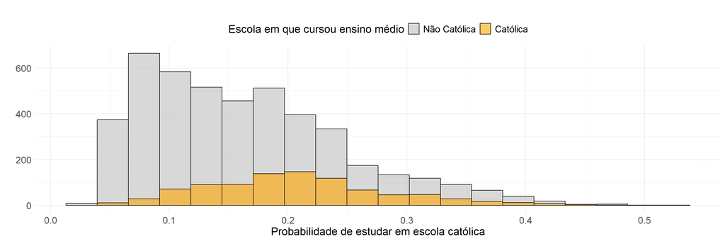

```r
# Criar o gráfico com sobreposição de histogramas e eixo x ajustado
ggplot(ecls, aes(x = pr_score, fill = factor(catholic))) +
  geom_histogram(alpha = 0.6, position = 'identity', bins = 20, color = "black") +
  scale_fill_manual(values = c("gray", "orange"),
                    labels = c("Não Católica", "Católica")) +
  labs(title = "",
       x = "Probabilidade de estudar em escola católica",
       y = "",
       fill = "Escola em que cursou ensino médio") +
  scale_x_continuous(breaks = seq(0, 1, by = 0.1)) +  # Ajuste do eixo x de 0,1 em 0,1
  theme_minimal() +
  theme(
    legend.position = "top", # Coloca a legenda no topo para melhor visualização
    text = element_text(size = 16), # Aumenta o tamanho geral do texto
    axis.text = element_text(size = 14), # Aumenta o tamanho dos textos dos eixos
    axis.title = element_text(size = 16), # Aumenta o tamanho dos títulos dos eixos
    legend.title = element_text(size = 16), # Aumenta o tamanho do título da legenda
    legend.text = element_text(size = 14)  # Aumenta o tamanho do texto da legenda
  )+
  theme(legend.position = "top") # Coloca a legenda no topo para melhor visualização
```

## 7.3 Aplicação do Matching

O objetivo do matching é equilibrar as características entre os dois grupos para tornar a comparação mais justa, como em um experimento randomizado.

No contexto de PSM, ele calcula as probabilidades de um indivíduo receber um tratamento com base em variáveis de confusão (ou covariáveis) e depois emparelha indivíduos com scores de propensão semelhantes nos grupos de tratamento e controle.

```r
mod_match <- matchit(catholic ~ race_white +
                       w3income_1k +
                       p5hmage +
                       p5numpla +
                       w3momed_hsb,
                       method = "nearest",
                       data=ecls)

dta_m <- match.data(mod_match) # Nova base criada a partir do matching
```

## 7.4 Base após matching

Inicialmente, havia 930 indivíduos tratados e 4.499 no controle. Após o pareamento, todos os 930 tratados foram pareados com 930 controles, resultando em 3.569 controles que não tinham contrapartida no grupo de tratamento e foram descartados

```r
resumo_mod_match <- summary(mod_match)

kable(resumo_mod_match$nn)
```

|  | Control | Treated |
| --- | --- | --- |
| All (ESS) | 4499 | 930 |
| All | 4499 | 930 |
| Matched (ESS) | 930 | 930 |
| Matched | 930 | 930 |
| Unmatched | 3569 | 0 |
| Discarded | 0 | 0 |

## 7.5 Balanceamento das Covariáveis

Após o pareamento, as **diferenças** entre os grupos de tratamento e controle foram **drasticamente reduzidas**, o que poderia enviesar a estimativa do efeito do tratamento se essas diferenças não fossem ajustadas.

```r
dta_m %>%
group_by(catholic) %>%
select(one_of(ecls_cov)) %>%
summarise_all(funs(mean)) %>%
gt()
```

| catholic | race_white | p5hmage | w3income_1k | p5numpla | w3momed_hsb |
| --- | --- | --- | --- | --- | --- |
| 0 | 0.7720430 | 39.63441 | 86.00858 | 1.052688 | 0.2043011 |
| 1 | 0.7666667 | 39.77527 | 86.18063 | 1.073118 | 0.2053763 |

- No início, ao realizar o teste t comparando as variáveis, todas apresentaram p-valor menor que 0,05.
- Após o pareamento, no entanto, não rejeitamos a hipótese nula, o que significa que, em relação a essas variáveis, o grupo de controle e o de tratamento são estatisticamente iguais.

```r
# Executando os testes t para cada variável
teste_raca_branca <- with(dta_m, t.test(race_white ~ catholic))  # Raça branca
teste_idade_mae <- with(dta_m, t.test(p5hmage ~ catholic))       # Idade da mãe
teste_renda <- with(dta_m, t.test(w3income_1k ~ catholic))       # Renda familiar
teste_num_lugares <- with(dta_m, t.test(p5numpla ~ catholic))    # Quantidade de lugares em que alunos moraram
teste_escolaridade_mae <- with(dta_m, t.test(w3momed_hsb ~ catholic))  # Escolaridade da mãe

# Criando um dataframe com o nome da variável, as médias de cada grupo, p-valor, estatística t e graus de liberdade
resultados <- data.frame(
  variavel = c("race_white", # Raça branca
               "p5hmage", # Idade da mãe
               "Renda familiar",
               "Quantidade de lugares morados",
               "Escolaridade da mãe"),
  `Não católico` = c(teste_raca_branca$estimate[1],
                   teste_idade_mae$estimate[1],
                   teste_renda$estimate[1],
                   teste_num_lugares$estimate[1],
                   teste_escolaridade_mae$estimate[1]),
  `Católico` = c(teste_raca_branca$estimate[2],
                   teste_idade_mae$estimate[2],
                   teste_renda$estimate[2],
                   teste_num_lugares$estimate[2],
                   teste_escolaridade_mae$estimate[2]),
  p_value = c(teste_raca_branca$p.value,
              teste_idade_mae$p.value,
              teste_renda$p.value,
              teste_num_lugares$p.value,
              teste_escolaridade_mae$p.value),
  statistic = c(teste_raca_branca$statistic,
                teste_idade_mae$statistic,
                teste_renda$statistic,
                teste_num_lugares$statistic,
                teste_escolaridade_mae$statistic))

resultados %>%
gt()
```

| variavel | Não.católico | Católico | p_value | statistic |
| --- | --- | --- | --- | --- |
| race_white | 0.7720430 | 0.7666667 | 0.78328817 | 0.27507634 |
| p5hmage | 39.6344086 | 39.7752688 | 0.51551196 | -0.65040365 |
| Renda familiar | 86.0085828 | 86.1806253 | 0.93276088 | -0.08438317 |
| Quantidade de lugares morados | 1.0526882 | 1.0731183 | 0.09782669 | -1.65632633 |
| Escolaridade da mãe | 0.2043011 | 0.2053763 | 0.95421539 | -0.05742178 |

## 7.6 Efeitos do tratamento

### 7.6.1 Teste t

Com os dados pareados, é simples calcular os efeitos do tratamento. Uma opção é usar o **teste t**.

```r
with(dta_m, t.test(c5r2mtsc_std ~ catholic))
```

```
##
##  Welch Two Sample t-test
##
## data:  c5r2mtsc_std by catholic
## t = 4.4425, df = 1847.3, p-value = 9.417e-06
## alternative hypothesis: true difference in means between group 0 and group 1 is not equal to 0
## 95 percent confidence interval:
##  0.1026983 0.2650474
## sample estimates:
## mean in group 0 mean in group 1
##       0.4035580       0.2196851
```

- Os resultados mostram uma **diferença significativa** nas notas de matemática entre **alunos católicos e não católicos**, com um *p-valor* muito pequeno (0.000009417).
- Em média, os alunos não católicos têm notas significativamente maiores do que os alunos católicos.

### 7.6.2 Regressão linear

Uma outra maneira de analisar é usar uma *regressão linear* da variável de interesse, que é a média de matemática, em relação ao tipo de escola:

```r
lm_treat1 <- lm(c5r2mtsc_std ~ catholic,data=dta_m)

summary(lm_treat1)
```

```
##
## Call:
## lm(formula = c5r2mtsc_std ~ catholic, data = dta_m)
##
## Residuals:
##     Min      1Q  Median      3Q     Max
## -3.4955 -0.5675  0.0332  0.6066  3.0301
##
## Coefficients:
##             Estimate Std. Error t value Pr(>|t|)
## (Intercept)  0.40356    0.02927  13.789  < 2e-16 ***
## catholic    -0.18387    0.04139  -4.443 9.41e-06 ***
## ---
## Signif. codes:  0 '***' 0.001 '**' 0.01 '*' 0.05 '.' 0.1 ' ' 1
##
## Residual standard error: 0.8925 on 1858 degrees of freedom
## Multiple R-squared:  0.01051,    Adjusted R-squared:  0.009978
## F-statistic: 19.74 on 1 and 1858 DF,  p-value: 9.414e-06
```

- Em média, ser aluno de uma escola católica está associado a uma redução de 0.18387 nas notas de matemática, em comparação com alunos de escolas não católicas.
- O sinal negativo mostra que, após ajustar para a variável, os alunos de escolas católicas tendem a ter desempenho inferior.

### 7.6.3 Regressão linear completa

Para sofisticar um pouco mais o modelo, além de incluir apenas a variável católica, podemos controlar pelas demais variáveis para verificar se obtemos estimativas mais eficientes:

```r
lm_treat2 <- lm(c5r2mtsc_std ~ catholic + race_white + w3income_1k + p5hmage + p5numpla + w3momed_hsb,
                data=dta_m)

summary(lm_treat2)
```

```
##
## Call:
## lm(formula = c5r2mtsc_std ~ catholic + race_white + w3income_1k +
##     p5hmage + p5numpla + w3momed_hsb, data = dta_m)
##
## Residuals:
##     Min      1Q  Median      3Q     Max
## -3.7095 -0.5353  0.0240  0.6104  2.8349
##
## Coefficients:
##               Estimate Std. Error t value Pr(>|t|)
## (Intercept) -0.6936331  0.1947415  -3.562 0.000378 ***
## catholic    -0.1826328  0.0393196  -4.645 3.64e-06 ***
## race_white   0.2682888  0.0468558   5.726 1.20e-08 ***
## w3income_1k  0.0030883  0.0004647   6.645 3.96e-11 ***
## p5hmage      0.0214028  0.0042952   4.983 6.84e-07 ***
## p5numpla    -0.1454435  0.0740612  -1.964 0.049699 *
## w3momed_hsb -0.3462700  0.0497587  -6.959 4.74e-12 ***
## ---
## Signif. codes:  0 '***' 0.001 '**' 0.01 '*' 0.05 '.' 0.1 ' ' 1
##
## Residual standard error: 0.8471 on 1853 degrees of freedom
## Multiple R-squared:  0.111,  Adjusted R-squared:  0.1081
## F-statistic: 38.57 on 6 and 1853 DF,  p-value: < 2.2e-16
```

- **O resultado se mantém**: alunos de escolas católicas têm desempenho em matemática pior do que alunos de escolas não católicas quando usamos uma estrutura de pareamento.

## 7.7 Conclusão

Mesmo controlando por atributos relevantes, **ainda encontramos diferenças nas médias de desempenho em matemática**.

Esse resultado sugere que **o tipo de escola influencia o desempenho**; alunos com perfis semelhantes obtêm resultados diferentes.

- Analisar apenas as médias levaria a uma conclusão incorreta, indicando que não há diferença entre os tipos de escola.
- No entanto, após o pareamento, comparando grupos muito semelhantes, observamos que **alunos de escolas não católicas** com trajetórias semelhantes aos de escolas católicas têm **melhores resultados em matemática**.

## 7.8 Referências

**R Tutorial 8: Propensity Score Matching**: https://simonejdemyr.com/r-tutorials/statistics/tutorial8.html

**Avaliação de politícas públicas B**: https://www.youtube.com/watch?v=uMJeojTOcxc&ab_channel=CanaldaQuaest

**HW11a - The Lost Homework on PSM and LASSO**: https://rpubs.com/metricsdawg/1037525